# Mizer-Fish-Model

Bethan Sleath

2026-02-21

## Setting up model

We set the parameters of the model to be a single species model with semi-chemostat growth resource dynamics. Initial conditions for resource and fish abundance are altered.

```r
params_single <- newSingleSpeciesParams()
params_single <- setResource(params_single,
                             resource_dynamics = "resource_semichemostat")

params_initial <- setResource(params_single,
                              resource_level = 0.05)

initialN(params_initial) <- 2*initialN(params_initial)
initialNResource(params_initial) <- initialNResource(params_initial)/2
```

## Fishing gear

Add a fishing gear to the model which uses a sigmoidal weight selectivity function

```r
gear_params(params_initial) <- data.frame(
  gear = "gear",
  species = "Target species",
  catchability = 1,
  sel_func = "sigmoid_weight",
  sigmoidal_weight = 25,
  sigmoidal_sigma = 10)

params_initial <- setFishing(params_initial, gear_params = gear_params)

gear_params(params_initial)
```

```
##                      gear        species catchability       sel_func
## Target species, gear gear Target species            1 sigmoid_weight
##                      sigmoidal_weight sigmoidal_sigma
## Target species, gear               25              10
```

## Initial model

### Calculate flux

Calculate the flux, the movement biomass between size classes, of the original system. The flux shown here is at t = 50, in the report the flux is shown over a 10 year period between t = 34 and t = 44.

```r
sim_initial <- project(params_initial, t_max = 50, effort = 0.125)

N <- finalN(sim_initial)["Target species", , drop = TRUE]
w <- w(params_initial)

E_growth <- getEGrowth(params_initial)["Target species", , drop = TRUE]
gr <- w * E_growth
flux <- gr * N

initial_flux_data <- data.frame(Weight = w,
                                Flux = flux)

plot_ly(initial_flux_data) |>
  add_lines(x = ~Weight, y = ~Flux) |>
  layout(yaxis = list(type = "log", exponentformat = "power",
                      title_text = "Flux (gm<sup>-2</sup>year<sup>-1</sup>)",
                      showline = TRUE, showgrid = FALSE, mirror = TRUE),
         xaxis = list(type = "log", exponentformat = "power",
                      title_text = "Weight (g)",
                      showline = TRUE, showgrid = FALSE, mirror = TRUE),
         margin = list(b = 65, l = 50))
```

[interactive chart not shown]

### Flux over a limited weight range

```r
initial_limited_flux <- data.frame(Weight = w[61:101],
                                   Flux = flux[61:101])

plot_ly(initial_limited_flux) |>
  add_lines(x = ~Weight, y = ~Flux) |>
  layout(yaxis = list(type = "log", exponentformat = "power",
                      title_text = "Flux (gm<sup>-2</sup>year<sup>-1</sup>)",
                      showline = TRUE, showgrid = FALSE, mirror = TRUE),
         xaxis = list(type = "log", exponentformat = "power",
                      title_text = "Weight (g)",
                      showline = TRUE, showgrid = FALSE, mirror = TRUE),
         margin = list(b = 65, l = 50))
```

[interactive chart not shown]

## System with reduced resource availability

### Locally reduce the resource rate and resource capacity

In order to model high competition between predators and a high density of fish within size classes, we locally reduce the resource rate and capacity to limit resource availability.

### Resource rate

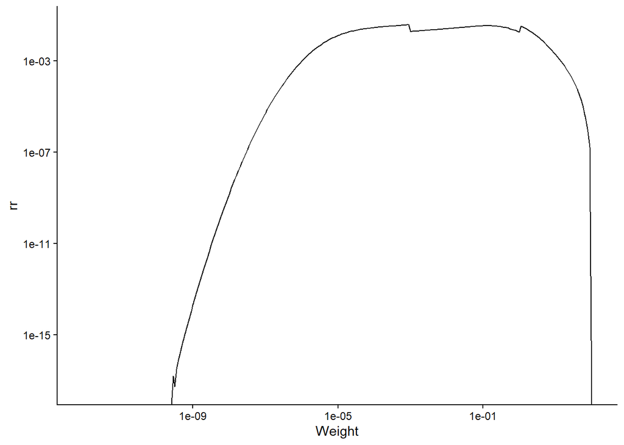

```r
rr <- resource_rate(params_initial)
w_full <- w_full(params_initial)
rr[182:242] <- rr[182:242] / 2

rr_data <- data.frame(
  Weight = params_initial@w_full,
  rr = rr)

rr_plot <- ggplot(rr_data,
                  aes(x = Weight, y = rr)) +
  geom_line() +
  scale_x_log10() +
  scale_y_log10() +
  theme_classic()
rr_plot
```

### Resource capacity

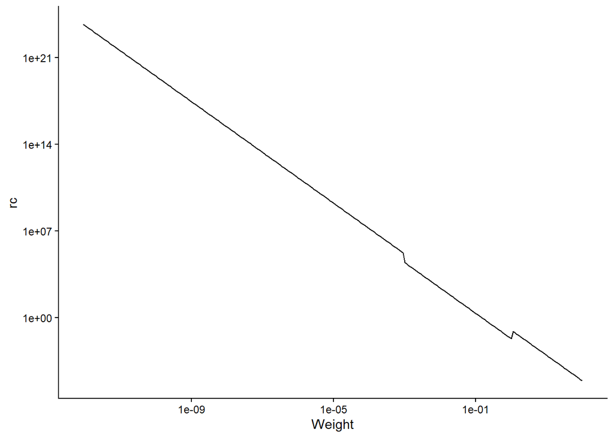

```r
rc <- resource_capacity(params_initial)
rc[182:242] <- rc[182:242] / 5

rc_data <- data.frame(Weight = params_initial@w_full,
                      rc = rc)

rc_plot <- ggplot(rc_data,
                  aes(x = Weight, y = rc)) +
  geom_line() +
  scale_x_log10() +
  scale_y_log10() +
  theme_classic()
rc_plot
```

### Set new parameters with reductions local reductions

```r
params_reduced <- setResource(params_initial,
                              resource_capacity = rc,
                              resource_rate = rr,
                              balance = FALSE)
```

## Narrow predation kernel

Another parameter we alter to model high competition is narrowing the predation kernel. This increases the specificity of predators food preference, and limits resource abundance.

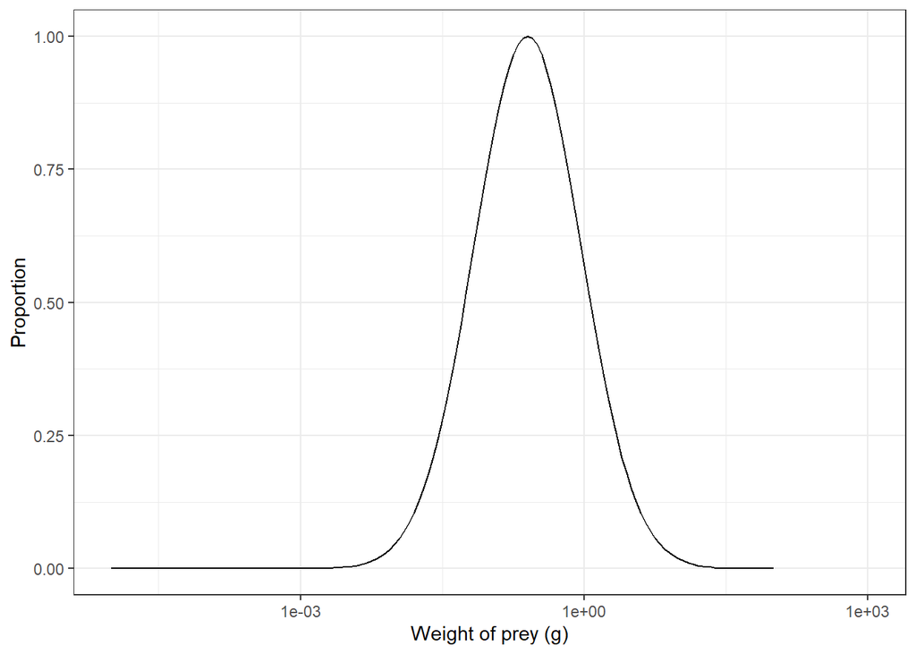

```r
pred_kernel <- getPredKernel(params_reduced)

pred_kernel_reduced <- pred_kernel[, 89, , drop = FALSE]

ggplot(melt(pred_kernel_reduced)) +
                            geom_line(aes(x = w_prey, y = value)) +
                            scale_x_log10("Weight of prey (g)", limits = c(1e-5, 1e03)) +
                            scale_y_continuous("Proportion", limits = c(0,1)) +
                            theme_bw()
```

```r
select(species_params(params_reduced), beta, sigma)
```

```
##                beta sigma
## Target species  100   1.3
```

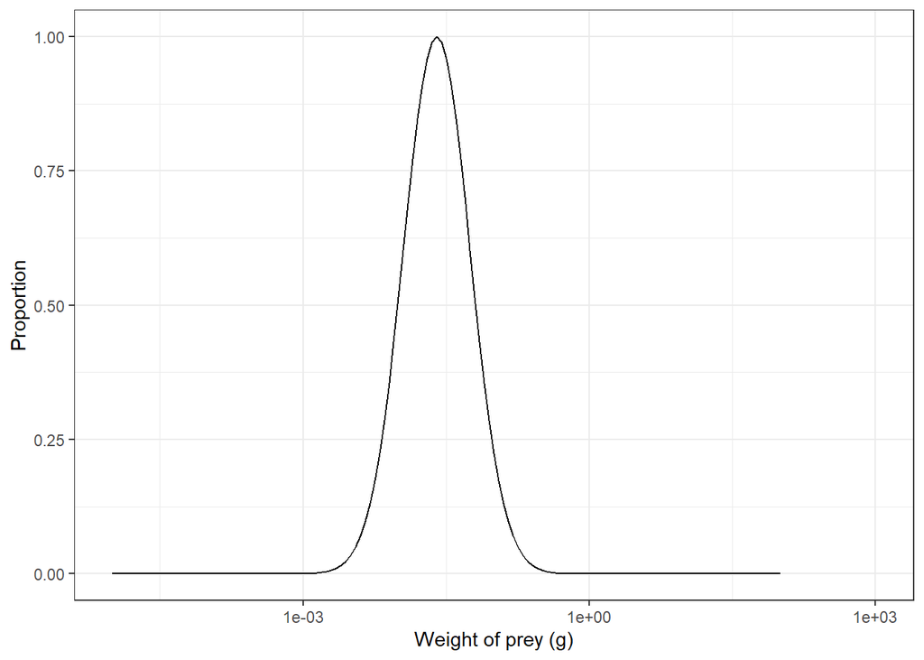

```r
params <- params_reduced

given_species_params(params)$sigma <- 0.8
given_species_params(params)$beta <- 1000

getPredKernel(params)[, 89, , drop = FALSE] %>%
  melt() %>%
  ggplot() +
  geom_line(aes(x = w_prey, y = value)) +
  scale_x_log10("Weight of prey (g)", limits = c(1e-5, 1e03)) +
  scale_y_continuous("Proportion")+
  theme_bw()
```

### Calculate flux of system

Calculate the flux of the system with modified resource dynamics. Once again, the flux shown here is at t = 50, in the report the flux is shown over a 10 year period between t = 34 and t = 44.

```r
sim_reduced <- project(params, t_max = 50, t_save = 0.1, effort = 4.6)

N_reduced <- finalN(sim_reduced)["Target species", , drop = TRUE]
w <- w(params)

E_growth_reduced <- getEGrowth(params)["Target species", , drop = TRUE]
grr <- w * E_growth_reduced
flux_reduced <- grr * N_reduced


reduced_flux_data <- data.frame(Weight = w,
                             Flux = flux_reduced)

plot_ly(reduced_flux_data) |>
  add_lines(x = ~Weight, y = ~Flux) |>
  layout(yaxis = list(type = "log", exponentformat = "power",
                      title_text = "Flux (gm<sup>-2</sup>year<sup>-1</sup>)",
                      showline = TRUE, showgrid = FALSE, mirror = TRUE),
         xaxis = list(type = "log", exponentformat = "power",
                      title_text = "Weight (g)",
                      showline = TRUE, showgrid = FALSE, mirror = TRUE),
         margin = list(b = 65, l = 50))
```

[interactive chart not shown]

### Flux over a limited weight range

```r
limited_flux_data <- data.frame(Weight = w[61:101],
                                Flux = flux_reduced[61:101])

plot_ly(limited_flux_data) |>
  add_lines(x = ~Weight, y = ~Flux) |>
  layout(yaxis = list(type = "log", exponentformat = "power",
                      title_text = "Flux (gm<sup>-2</sup>year<sup>-1</sup>)",
                      showline = TRUE, showgrid = FALSE, mirror = TRUE),
         xaxis = list(type = "log", exponentformat = "power",
                      title_text = "Weight (g)",
                      showline = TRUE, showgrid = FALSE, mirror = TRUE),
         margin = list(b = 65, l = 50))
```

[interactive chart not shown]

## Growth rate

### Reduced resource system

We plot the growth rate of the fish population in the ecosystem.

```r
growth_data <- data.frame(growth = E_growth_reduced,
                          weight = w)

plot_ly(growth_data) |>
  add_lines(x = ~weight, y = ~growth) |>
  layout(yaxis = list(title_text = "Growth Rate (g/year)",
                      range = c(0, 20),
                      showline = TRUE, showgrid = FALSE, zeroline = FALSE, mirror = TRUE),
         xaxis = list(type = "log", exponentformat = "power",
                      title_text = "Weight (g)",
                      showline = TRUE, showgrid = FALSE, mirror = TRUE),
         margin = list(b = 65, l = 65))
```

[interactive chart not shown]

### Comparative growth rate

Comparison between the growth rate of fish in the original system to the fish in reduced resource system.

```r
gf_original <- melt(getEGrowth(params_single))
gf_original$Model <- "Original"
gf_starved <- melt(getEGrowth(params))
gf_starved$Model <- "Less prey"
gf_total <- rbind(gf_original, gf_starved)

plot_ly(gf_total) |>
  add_lines(x = ~w, y = ~value, color = ~Model) |>
  layout(yaxis = list(title_text = "Growth rate (g/year)",
                      showline = TRUE, showgrid = FALSE, mirror = TRUE, zeroline = FALSE,
                      range = c(0,40)),
         xaxis = list(type = "log", exponentformat = "power",
                      title_text = "Weight (g)",
                      showline = TRUE, showgrid = FALSE, mirror = TRUE),
         margin = list(b = 65, l = 65))
```

[interactive chart not shown]

## Biomass density spectra

### Reduced resource system

Plot the spectra to see the biomass density across weight classes of the system. The biomass density is plotted at t = 50 here in line with the flux graphs, in the report it is plotted at t = 36 where the ‘traffic jam’ is most prevalent.

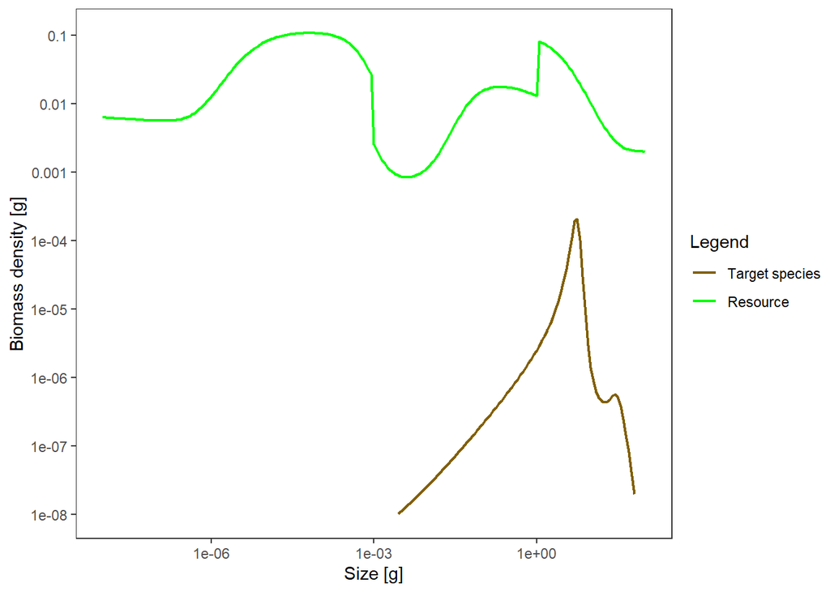

```r
plotSpectra(sim_reduced, power = 2, wlim = c(1e-8, NA), ylim = c(1e-8, NA),
            time_range = 50)+
  theme_test()
```

### Comparative biomass density spectra

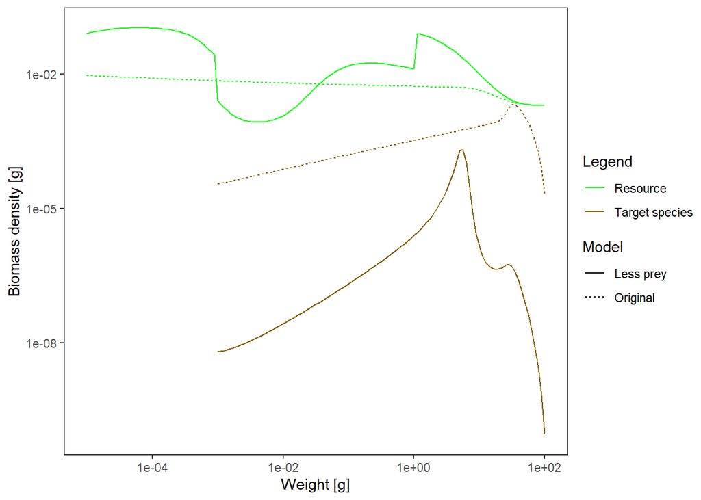

```r
plotSpectra2(sim_initial, name1 = "Original",
             sim_reduced, name2 = "Less prey",
             power = 2, time_range = 50) +
  theme_test()
```

## Animations

We create animations to look at modelled changes over time for the modified model.

### Biomass abundance

```r
nf <- melt(sim_reduced@n)
n_ppf <- melt(sim_reduced@n_pp)
n_ppf$sp <- "Resource"
nf <- rbind(nf, n_ppf)

plot_ly(nf) |>
  filter(w > 10^-5) |>
  mutate(b = value * w^2) |>
  add_lines(
    x = ~w, y = ~b,
    color = ~sp,
    frame = ~time,
    line = list(simplify = FALSE)) |>
  layout(params, xaxis = list(type = "log", exponentformat = "power",
                         title_text = "body mass (g)"),
         yaxis = list(type = "log", exponentformat = "power",
                      title_text = "biomass (g/m^3)",
                      range = c(-9, 0)))
```

[interactive chart not shown]

### Flux

```r
species <- "Target species"
time <- getTimes(sim_reduced)

flux_series <- lapply(seq_along(time), function(i) {
  n_at_t <- sim_reduced@n[i, species, ]
  data.frame(
    Time = time[i],
    Weight = w,
    Flux = n_at_t * grr)}) |>  bind_rows()

flux_series$Species <- species

plot_ly(flux_series) |>
  add_lines(x ~Weight,
            y ~Flux,
            color = ~Species,
            frame = ~Time,
            line = list(simplify = FALSE)) |>
  layout(params, xaxis = list(type = "log", exponentformat = "power",
                         title_text = "body mass (g)"),
         yaxis = list(type = "log", exponentformat = "power",
                      title_text = "flux (gm<sup>-2</sup>year<sup>-1</sup>)",
                      range = c(-9, 0)))
```

[interactive chart not shown]

## Altering fishing effort

All previous simulations have been run using maximum sustainable yield, or an approximation. We now alter the fishing effort to see the impact on modelled functions.

### Flux with lower fishing effort

Effort was changed to 0.5.

```r
sim_lower <- project(params, t_max = 50, t_save = 0.1, effort = 0.5)

N_lower <- finalN(sim_lower)["Target species", , drop = TRUE]
flux_lower <- grr * N_lower

lower_flux_data <- data.frame(Weight = w,
                                Flux = flux_lower)

plot_ly(lower_flux_data) |>
  add_lines(x = ~Weight, y = ~Flux) |>
  layout(yaxis = list(type = "log", exponentformat = "power",
                      title_text = "Flux (gm<sup>-2</sup>year<sup>-1</sup>)",
                      showline = TRUE, showgrid = FALSE, mirror = TRUE),
         xaxis = list(type = "log", exponentformat = "power",
                      title_text = "Weight (g)",
                      showline = TRUE, showgrid = FALSE, mirror = TRUE),
         margin = list(b = 65, l = 50))
```

[interactive chart not shown]

### Flux with higher fishing effort

Effort was changed to 10.

```r
sim_higher <- project(params, t_max = 50, t_save = 0.1, effort = 10)

N_higher <- finalN(sim_higher)["Target species", , drop = TRUE]
flux_higher <- grr * N_higher

higher_flux_data <- data.frame(Weight = w,
                                Flux = flux_higher)
plot_ly(higher_flux_data) |>
  add_lines(x = ~Weight, y = ~Flux) |>
  layout(yaxis = list(type = "log", exponentformat = "power",
                      title_text = "Flux (gm<sup>-2</sup>year<sup>-1</sup>)",
                      showline = TRUE, showgrid = FALSE, mirror = TRUE),
         xaxis = list(type = "log", exponentformat = "power",
                      title_text = "Weight (g)",
                      showline = TRUE, showgrid = FALSE, mirror = TRUE),
         margin = list(b = 65, l = 75))
```

[interactive chart not shown]

## Compare flux between fishing efforts

Once again, this comparison is shown at t = 50, where in the report the flux comparison is plotted over a 10 year period between t = 34 and t = 44.

```r
reduced_flux_data$Sim <- NULL
reduced_flux_data$Effort = "MSY"
lower_flux_data$Effort = "Lower fishing effort"
higher_flux_data$Effort = "Higher fishing effort"


fishing_flux <- rbind(higher_flux_data, lower_flux_data, reduced_flux_data)

plot_ly(fishing_flux) |>
  add_lines(x = ~Weight, y = ~Flux, color = ~Effort, linetype = ~Effort) |>
  layout(yaxis = list(type = "log", exponentformat = "power",
                      title_text = "Flux (gm<sup>-2</sup>year<sup>-1</sup>)",
                      showline = TRUE, showgrid = FALSE, mirror = TRUE, range = c(-12,-2)),
         xaxis = list(type = "log", exponentformat = "power",
                      title_text = "Weight (g)",
                      showline = TRUE, showgrid = FALSE, mirror = TRUE),
         margin = list(b = 65, l = 75))
```

[interactive chart not shown]

## Yield

### Maximum sustainable yield

We plot the yield at our approximated MSY.

```r
sim_medium <- project(params, t_max = 100, t_save = 0.1, effort = 4.6)

yield <- getYield(sim_medium)
times <- getTimes(sim_medium)

yield_data <- data.frame(Time = times,
                         Yield = yield)

plot_ly(yield_data) |>
  filter(times >= 50) |>
  add_lines(x = ~Time, y = ~Target.species) |>
  layout(yaxis = list(type = "log", exponentformat = 'power',
                      title = "Yield (g/year)",
                      showline = TRUE, showgrid = FALSE, mirror = TRUE,
                        range = c(-7, -2)),
         xaxis = list(title = "Year",
                      showline = TRUE, showgrid = FALSE, mirror = TRUE),
         margin = list(b = 65, l = 70))
```

[interactive chart not shown]

### Lower effort

We plot the yield with lower fishing effort.

```r
sim_low_yield <- project(params, t_max = 100, t_save = 0.1, effort = 0.5)
yield_lower <- getYield(sim_low_yield)

yield_lower_data <- data.frame(Time = times,
                               Yield = yield_lower)

plot_ly(yield_lower_data) |>
  filter(times >= 50) |>
  add_lines(x = ~Time, y = ~Target.species) |>
  layout(yaxis = list(type = "log", exponentformat = 'power',
                      title_text = "Yield (g/year)",
                      showline = TRUE, showgrid = FALSE, mirror = TRUE,
                      range = c(-7, -2)),
         xaxis = list(title_text = "Year",
                      showline = TRUE, showgrid = FALSE, mirror = TRUE),
         margin = list(b = 65, l = 70))
```

[interactive chart not shown]

### Higher fishing effort

We plot the yield with higher fishing effort.

```r
sim_high_yield <- project(params, t_max = 100, t_save = 0.1,  effort = 10)
yield_heavy <- getYield(sim_high_yield)

yield_heavy_data <- data.frame(Time = times,
                         Yield = yield_heavy)

plot_ly(yield_heavy_data) |>
  filter(times >= 50) |>
  add_lines(x = ~Time, y = ~Target.species) |>
  layout(yaxis = list(type = "log", exponentformat = 'power',
                      title_text = "Yield (g/year)",
                      showline = TRUE, showgrid = FALSE, mirror = TRUE,
                      range = c(-7, -2)),
         xaxis = list(title_text = "Year",
                      showline = TRUE, showgrid = FALSE, mirror = TRUE),
         margin = list(b = 65, l = 70))
```

[interactive chart not shown]

### Time dependent fishing effort

We experimented with changing the fishing effort in accordance to the yield. When the peaks of yield was reached, based on the MSY graph, the effort was reduced to the lower fishing effort. Otherwise the effort remained at a level to produce MSY.

```r
t_total <- 200
med_effort <- 4.6
low_effort <- 0.5
threshold_value <- 0.00022
current_effort <- med_effort


sim_combined <- project(params, t_max = 1, t_save = 0.1, effort = current_effort)

last_yield <- getYield(sim_combined)[idxFinalT(sim_combined), "Target species"]
if (last_yield >= threshold_value) {
  current_effort <- low_effort
} else {
  current_effort <- med_effort
}

for (t in 2:t_total) {
  sim_combined <- project(sim_combined, t_max = 1, t_save = 0.1, effort = current_effort, append = TRUE)

  last_yield <- getYield(sim_combined)[idxFinalT(sim_combined), "Target species"]

  if (last_yield >= threshold_value) {
    current_effort <- low_effort
  } else {
    current_effort <- med_effort
  }
}

yield_fishing <- getYield(sim_combined)

time = getTimes(sim_combined)

yield_fishing_data <- data.frame(Time = time,
                                 Yield = yield_fishing)

plot_ly(yield_fishing_data) |>
  filter(time >= 150) |>
  add_lines(x = ~Time, y = ~Target.species) |>
  layout(yaxis = list(type = "log", exponentformat = 'power',
                      title_text = "Yield (g/year)",
                      showline = TRUE, showgrid = FALSE, mirror = TRUE,
                      range = c(-7, -2)),
         xaxis = list(title_text = "Year",
                      showline = TRUE, showgrid = FALSE, mirror = TRUE),
         margin = list(b = 65, l = 70))
```

[interactive chart not shown]

### Changing effort

```r
effort_df <- melt(getEffort(sim_combined))

plot_ly(effort_df) |>
  filter(time >= 100) |>
  add_lines(x = ~time, y = ~value) |>
  layout(yaxis = list(title_text = "Effort",
                      showline = TRUE, showgrid = FALSE, mirror = TRUE),
         xaxis = list(title_text = "Time (year)", range = c(100, 200),
                      showline = TRUE, showgrid = FALSE, mirror = TRUE),
         margin = list(b = 65, l = 70))
```

[interactive chart not shown]